# Econometrics Project

Steven Trochez, Habiba Sultana

12/21/2019

The data is extracted from IPUMS/NHIS database. Courtsy of Lynn A. Blewett, Julia A. Rivera Drew, Miriam L. King and Kari C.W. Williams. IPUMS Health Surveys: National Health Interview Survey, Version 6.4 [dataset]. Minneapolis, MN: IPUMS, 2019. https://doi.org/10.18128/D070.V6.4 http://www.nhis.ipums.org

```r
#Installing the neccesarry packages:
library(data.table)
library(dplyr)
```

```r
library(igraph)
library(DataExplorer)
library(jtools)
library("naniar")
library(ggplot2)
library("ipumsr")
library(AER)
```

#Exporting and importing Data: The data is accessible through the website (http://www.nhis.ipums.org). The Variables are chosen from a variaty of different options. The variables were chosen based on the requirments of the general question of the analysis.

```r
# Import the data file from local directory:
ddi <- read_ipums_ddi("nhis_00007.xml")
data <- read_ipums_micro(ddi)
```

```
## Use of data from NHIS is subject to conditions including that users should cite
## the data appropriately. Use command `ipums_conditions()` for more details.
```

```r
#Summary of Data:
glimpse(data)
```

```
## Observations: 868,476
## Variables: 39
## $ YEAR        <dbl> 2010, 2010, 2010, 2010, 2010, 2010, 2010, 2010, 2010…
## $ SERIAL      <dbl> 1, 1, 1, 2, 2, 2, 3, 3, 3, 3, 5, 6, 6, 6, 6, 9, 9, 9…
## $ STRATA      <dbl+lbl> 6001, 6001, 6001, 6249, 6249, 6249, 6045, 6045, …
## $ PSU         <dbl+lbl> 2, 2, 2, 2, 2, 2, 2, 2, 2, 2, 1, 2, 2, 2, 2, 2, …
## $ NHISHID     <chr> "00002010000001", "00002010000001", "00002010000001"…
## $ HHWEIGHT    <dbl> 3042, 3042, 3042, 1124, 1124, 1124, 3713, 3713, 3713…
## $ REGION      <int+lbl> 1, 1, 1, 4, 4, 4, 1, 1, 1, 1, 2, 1, 1, 1, 1, 2, …
## $ PERNUM      <dbl> 1, 2, 3, 1, 2, 3, 1, 2, 3, 4, 1, 1, 2, 3, 4, 1, 2, 3…
## $ NHISPID     <chr> "0020100000010101", "0020100000010102", "00201000000…
## $ HHX         <chr> "000001", "000001", "000001", "000002", "000002", "0…
## $ FMX         <chr> "01", "01", "01", "01", "01", "01", "01", "01", "01"…
## $ PX          <chr> "01", "02", "03", "01", "02", "03", "01", "02", "03"…
## $ PERWEIGHT   <dbl> 3248, 3981, 3181, 1454, 1370, 1607, 4661, 4396, 4228…
```

[output cut: 26 more lines]

```r
summary(data)
```

```
##       YEAR          SERIAL          STRATA          PSU
##  Min.   :2010   Min.   :    1   Min.   :6001   Min.   :  1.00
##  1st Qu.:2012   1st Qu.:12993   1st Qu.:6114   1st Qu.:  1.00
##  Median :2014   Median :25967   Median :6225   Median :  2.00
##  Mean   :2014   Mean   :26424   Mean   :6435   Mean   : 10.31
##  3rd Qu.:2016   3rd Qu.:39159   3rd Qu.:7105   3rd Qu.:  2.00
##  Max.   :2018   Max.   :60347   Max.   :7151   Max.   :164.00
##
##    NHISHID             HHWEIGHT         REGION          PERNUM
##  Length:868476      Min.   :   51   Min.   :1.000   Min.   : 1.000
##  Class :character   1st Qu.: 1467   1st Qu.:2.000   1st Qu.: 1.000
##  Mode  :character   Median : 2503   Median :3.000   Median : 2.000
##                     Mean   : 2712   Mean   :2.747   Mean   : 2.194
##                     3rd Qu.: 3650   3rd Qu.:4.000   3rd Qu.: 3.000
##                     Max.   :23334   Max.   :4.000   Max.   :18.000
##
##    NHISPID              HHX                FMX
##  Length:868476      Length:868476      Length:868476
##  Class :character   Class :character   Class :character
##  Mode  :character   Mode  :character   Mode  :character
##
##
##
##
##       PX              PERWEIGHT       SAMPWEIGHT        FWEIGHT
##  Length:868476      Min.   :    0   Min.   :     0   Min.   :   50
##  Class :character   1st Qu.: 1804   1st Qu.:     0   1st Qu.: 1676
##  Mode  :character   Median : 3030   Median :     0   Median : 2835
##                     Mean   : 3247   Mean   :  3247   Mean   : 3048
##                     3rd Qu.: 4345   3rd Qu.:  4995   3rd Qu.: 4094
##                     Max.   :32717   Max.   :236830   Max.   :29261
##
##     ASTATFLG        CSTATFLG           AGE             SEX
##  Min.   :0.000   Min.   :0.0000   Min.   : 0.00   Min.   :1.000
##  1st Qu.:1.000   1st Qu.:0.0000   1st Qu.:18.00   1st Qu.:1.000
##  Median :1.000   Median :0.0000   Median :37.00   Median :2.000
##  Mean   :1.522   Mean   :0.4997   Mean   :37.55   Mean   :1.516
##  3rd Qu.:3.000   3rd Qu.:0.0000   3rd Qu.:56.00   3rd Qu.:2.000
##  Max.   :5.000   Max.   :5.0000   Max.   :85.00   Max.   :2.000
##
```

[output cut: 25 more lines]

```
##  Min.   :0.0000   Min.   : 1.0   Min.   :0.0000   Min.   : 1.00
##  1st Qu.:0.0000   1st Qu.:96.0   1st Qu.:0.0000   1st Qu.:96.00
##  Median :0.0000   Median :96.0   Median :0.0000   Median :96.00
##  Mean   :0.1884   Mean   :94.4   Mean   :0.8301   Mean   :91.35
##  3rd Qu.:0.0000   3rd Qu.:96.0   3rd Qu.:2.0000   3rd Qu.:96.00
##  Max.   :9.0000   Max.   :99.0   Max.   :9.0000   Max.   :99.00
##
##   SMOKFREQNOW        MOD10DTP        HRSLEEP            ASAD
##  Min.   :0.0000   Min.   :0.000   Min.   : 0.000   Min.   :0.000
##  1st Qu.:0.0000   1st Qu.:0.000   1st Qu.: 0.000   1st Qu.:1.000
##  Median :0.0000   Median :0.000   Median : 0.000   Median :6.000
##  Mean   :0.2318   Mean   :0.253   Mean   : 3.063   Mean   :4.231
##  3rd Qu.:0.0000   3rd Qu.:0.000   3rd Qu.: 6.000   3rd Qu.:6.000
##  Max.   :9.0000   Max.   :9.000   Max.   :99.000   Max.   :9.000
##
```

#Data Cleaning: There are three types of missing data (NIU, unknown-refused, uknown-not ascertined, unknown-don’t know), the data will be subsetted discarding these values.

```r
## Cleaning Data (Removing NA), Creating  tidy data:
data1<-replace_with_na(data, replace = list(EDUC=c(000, 996, 997, 998,999),
                                              RACEA=c(900,970,980,990),
                                              REGION=c(08,09),
                                              ASTHMAEV=c(0,7,8,9),
                                              CHEARTDIEV=c(0,7,8,9),
                                              ALCSTAT1=c(0,9),
                                              CIGSDAY=c(00,96,97,98,99),
                                              VISITYRNO=c(00,96,97,98,99),
                                              HINOTCOV=c(00,09),
                                              HEARTCONEV=c(0,7,8,9),
                                              STROKEV=c(0,7,8,9),
                                              ARTHLIMIT=c(0,7,8,9),
                                              DIABETICAGE=c(00,96,97,98,99),
                                              HEALTH=c(0,7,8,9),
                                              ALCSTAT1=c(0,9),
                                              SMOKFREQNOW=c(0,7,8,9),
                                              ASAD=c(0,6,7,8,9),
                                              MOD10DTP=c(0,7,8,9),
                                              HRSLEEP=c(00,97,98,99)))
```

#SUMMARAZING THE DATA:

```r
summary(data1)
```

```
##       YEAR          SERIAL          STRATA          PSU
##  Min.   :2010   Min.   :    1   Min.   :6001   Min.   :  1.00
##  1st Qu.:2012   1st Qu.:12993   1st Qu.:6114   1st Qu.:  1.00
##  Median :2014   Median :25967   Median :6225   Median :  2.00
##  Mean   :2014   Mean   :26424   Mean   :6435   Mean   : 10.31
##  3rd Qu.:2016   3rd Qu.:39159   3rd Qu.:7105   3rd Qu.:  2.00
##  Max.   :2018   Max.   :60347   Max.   :7151   Max.   :164.00
##
##    NHISHID             HHWEIGHT         REGION          PERNUM
##  Length:868476      Min.   :   51   Min.   :1.000   Min.   : 1.000
##  Class :character   1st Qu.: 1467   1st Qu.:2.000   1st Qu.: 1.000
##  Mode  :character   Median : 2503   Median :3.000   Median : 2.000
##                     Mean   : 2712   Mean   :2.747   Mean   : 2.194
##                     3rd Qu.: 3650   3rd Qu.:4.000   3rd Qu.: 3.000
##                     Max.   :23334   Max.   :4.000   Max.   :18.000
##
##    NHISPID              HHX                FMX
##  Length:868476      Length:868476      Length:868476
##  Class :character   Class :character   Class :character
##  Mode  :character   Mode  :character   Mode  :character
##
##
##
##
##       PX              PERWEIGHT       SAMPWEIGHT        FWEIGHT
##  Length:868476      Min.   :    0   Min.   :     0   Min.   :   50
##  Class :character   1st Qu.: 1804   1st Qu.:     0   1st Qu.: 1676
##  Mode  :character   Median : 3030   Median :     0   Median : 2835
##                     Mean   : 3247   Mean   :  3247   Mean   : 3048
##                     3rd Qu.: 4345   3rd Qu.:  4995   3rd Qu.: 4094
##                     Max.   :32717   Max.   :236830   Max.   :29261
##
##     ASTATFLG        CSTATFLG           AGE             SEX
##  Min.   :0.000   Min.   :0.0000   Min.   : 0.00   Min.   :1.000
##  1st Qu.:1.000   1st Qu.:0.0000   1st Qu.:18.00   1st Qu.:1.000
##  Median :1.000   Median :0.0000   Median :37.00   Median :2.000
##  Mean   :1.522   Mean   :0.4997   Mean   :37.55   Mean   :1.516
##  3rd Qu.:3.000   3rd Qu.:0.0000   3rd Qu.:56.00   3rd Qu.:2.000
##  Max.   :5.000   Max.   :5.0000   Max.   :85.00   Max.   :2.000
##
```

[output cut: 25 more lines]

```
##  Min.   :1.0      Min.   : 1.0     Min.   :1.0      Min.   : 1
##  1st Qu.:1.0      1st Qu.:40.0     1st Qu.:2.0      1st Qu.: 5
##  Median :1.0      Median :50.0     Median :3.0      Median :10
##  Mean   :1.4      Mean   :48.4     Mean   :2.4      Mean   :12
##  3rd Qu.:2.0      3rd Qu.:60.0     3rd Qu.:3.0      3rd Qu.:20
##  Max.   :2.0      Max.   :85.0     Max.   :3.0      Max.   :90
##  NA's   :749101   NA's   :839229   NA's   :587878   NA's   :820385
##   SMOKFREQNOW        MOD10DTP         HRSLEEP            ASAD
##  Min.   :1.0      Min.   :1.0      Min.   : 1.0     Min.   :1.0
##  1st Qu.:1.0      1st Qu.:1.0      1st Qu.: 6.0     1st Qu.:1.0
##  Median :1.0      Median :1.0      Median : 7.0     Median :1.0
##  Mean   :1.8      Mean   :1.3      Mean   : 7.1     Mean   :1.6
##  3rd Qu.:3.0      3rd Qu.:2.0      3rd Qu.: 8.0     3rd Qu.:2.0
##  Max.   :3.0      Max.   :2.0      Max.   :24.0     Max.   :4.0
##  NA's   :754264   NA's   :702535   NA's   :590616   NA's   :795612
```

```r
attach(data1)
```

#CREATING MORE DESCRIPTIVE CATEGORIES ACCORDING TO THE IPUMS/NHIS CODEBOOK:

```r
#REGION:
REGION <- as.factor(REGION)
levels(REGION) <- c("Northeast","Midwest","South","West")
#AGE:
age<-as.numeric(AGE)
#SEX:
female <- as.numeric(SEX == 2)
#EDUCATION:
educ_nohs <- as.numeric(EDUC == 200)
educ_hs <- as.numeric((EDUC > 204) | (EDUC == 301))
educ_smcoll <- as.numeric(EDUC > 400) & (EDUC == 401)
educ_as <- as.numeric((EDUC > 402) & (EDUC < 403))
educ_bach <- as.numeric(EDUC == 500)
educ_adv <- as.numeric((EDUC > 600) & (EDUC < 603))
#RACE:
white <- as.numeric(RACEA == 100)
black <- as.numeric(RACEA == 200)
native <- as.numeric(RACEA == 300)
asian <- as.numeric(RACEA == 410)
#HEALTH:
HEALTH <- as.numeric(HEALTH == 1) | (HEALTH == 2) | (HEALTH == 3) | (HEALTH == 4) | (HEALTH == 5)
#BMI:
BMI <-as.numeric(BMI)
#DOCTOR VISITS:
VISITYRNO <-as.numeric(VISITYRNO > 10) & (VISITYRNO < 40)
#HEALTH INSURANCE:
HINOTCOV <-as.numeric(HINOTCOV == 1) | (HINOTCOV == 2)
#ASTHMA:
ASTHMAEV <-as.numeric(ASTHMAEV == 2)
#HEART DISEASE:
CHEARTDIEV <-as.numeric(CHEARTDIEV == 2)
#HIGH COLESTEROL:
CHOLHIGHEV <-as.numeric(CHOLHIGHEV == 2)
#HEART CONDITION:
HEARTCONEV <-as.numeric(HEARTCONEV == 2)
#STROKE:
STROKEV <-as.numeric(STROKEV == 2)
#ARTHRITIS:
ARTHLIMIT <-as.numeric(ARTHLIMIT == 2)
#AGE DIAGNOSE WITH DIABETES:
DIABETICAGE <-as.numeric(DIABETICAGE > 01) & (DIABETICAGE < 65)
#ALCOHOL STATUS:
ALCSTAT1 <-as.numeric(ALCSTAT1 == 1) | (ALCSTAT1 == 2) | (ALCSTAT1 == 3)
#NUMBER OF CIGARETTES PER DAY:
CIGSDAY <-as.numeric(CIGSDAY>01) & (CIGSDAY<20)
#SMOKE FREQUENCY:
SMOKFREQNOW <-as.numeric(SMOKFREQNOW == 2) | (SMOKFREQNOW == 3)
#ACTIVITY DURATION:
MOD10DTP <-as.numeric(MOD10DTP == 1) | (MOD10DTP == 2)
#HOURS OF SLEEP PER DAY:
HRSLEEP <-as.numeric(HRSLEEP>01) & (HRSLEEP<08)
#HOW OFTEN DO YOU FEEL SAD:
ASAD <-as.numeric(ASAD>1) & (ASAD<4)
```

#CREATING A NEW DATASET:

```r
newdata <-data.frame(REGION,female,educ_nohs,educ_hs,educ_smcoll,educ_as,educ_bach,educ_adv,white,black,asian,native,HEALTH,VISITYRNO,HINOTCOV,ASTHMAEV,CHEARTDIEV,CHOLHIGHEV,HEARTCONEV,STROKEV,ARTHLIMIT,DIABETICAGE,ALCSTAT1,CIGSDAY,SMOKFREQNOW,MOD10DTP,HRSLEEP,ASAD,YEAR,SERIAL,STRATA,PSU,NHISHID,HHWEIGHT,HHX,PX,PERWEIGHT,SAMPWEIGHT,FWEIGHT,ASTATFLG,CSTATFLG,age,BMI)

detach()
attach(newdata)
summary(newdata)
```

```
##        REGION           female         educ_nohs        educ_hs
##  Northeast:140744   Min.   :0.0000   Min.   :0       Min.   :0.00
##  Midwest  :177931   1st Qu.:0.0000   1st Qu.:0       1st Qu.:0.00
##  South    :309825   Median :1.0000   Median :0       Median :1.00
##  West     :239976   Mean   :0.5161   Mean   :0       Mean   :0.68
##                     3rd Qu.:1.0000   3rd Qu.:0       3rd Qu.:1.00
##                     Max.   :1.0000   Max.   :0       Max.   :1.00
##                                      NA's   :69039   NA's   :69039
##  educ_smcoll        educ_as        educ_bach        educ_adv
##  Mode :logical   Min.   :0       Min.   :0.00    Min.   :0.00
##  FALSE:676240    1st Qu.:0       1st Qu.:0.00    1st Qu.:0.00
##  TRUE :123197    Median :0       Median :0.00    Median :0.00
##  NA's :69039     Mean   :0       Mean   :0.14    Mean   :0.07
##                  3rd Qu.:0       3rd Qu.:0.00    3rd Qu.:0.00
##                  Max.   :0       Max.   :1.00    Max.   :1.00
##                  NA's   :69039   NA's   :69039   NA's   :69039
##      white            black            asian       native   HEALTH
##  Min.   :0.0000   Min.   :0.0000   Min.   :0   Min.   :0   Mode:logical
##  1st Qu.:1.0000   1st Qu.:0.0000   1st Qu.:0   1st Qu.:0   TRUE:867438
##  Median :1.0000   Median :0.0000   Median :0   Median :0   NA's:1038
##  Mean   :0.7653   Mean   :0.1428   Mean   :0   Mean   :0
##  3rd Qu.:1.0000   3rd Qu.:0.0000   3rd Qu.:0   3rd Qu.:0
##  Max.   :1.0000   Max.   :1.0000   Max.   :0   Max.   :0
##
##  VISITYRNO       HINOTCOV          ASTHMAEV        CHEARTDIEV
##  Mode :logical   Mode:logical   Min.   :0.0      Min.   :0.0
##  FALSE:117803    TRUE:860147    1st Qu.:0.0      1st Qu.:0.0
##  TRUE :206099    NA's:8329      Median :0.0      Median :0.0
##  NA's :544574                   Mean   :0.1      Mean   :0.1
##                                 3rd Qu.:0.0      3rd Qu.:0.0
##                                 Max.   :1.0      Max.   :1.0
##                                 NA's   :479854   NA's   :584196
##    CHOLHIGHEV       HEARTCONEV        STROKEV         ARTHLIMIT
##  Min.   :0.0      Min.   :0.0      Min.   :0        Min.   :0.0
##  1st Qu.:0.0      1st Qu.:0.0      1st Qu.:0        1st Qu.:0.0
##  Median :0.0      Median :0.0      Median :0        Median :0.0
##  Mean   :0.1      Mean   :0.1      Mean   :0        Mean   :0.4
##  3rd Qu.:0.0      3rd Qu.:0.0      3rd Qu.:0        3rd Qu.:1.0
##  Max.   :1.0      Max.   :1.0      Max.   :1        Max.   :1.0
##  NA's   :408424   NA's   :583963   NA's   :583932   NA's   :749101
```

[output cut: 33 more lines]

```
##  Min.   :     0   Min.   :   50   Min.   :0.000   Min.   :0.0000
##  1st Qu.:     0   1st Qu.: 1676   1st Qu.:1.000   1st Qu.:0.0000
##  Median :     0   Median : 2835   Median :1.000   Median :0.0000
##  Mean   :  3247   Mean   : 3048   Mean   :1.522   Mean   :0.4997
##  3rd Qu.:  4995   3rd Qu.: 4094   3rd Qu.:3.000   3rd Qu.:0.0000
##  Max.   :236830   Max.   :29261   Max.   :5.000   Max.   :5.0000
##
##       age             BMI
##  Min.   : 0.00   Min.   : 0.000
##  1st Qu.:18.00   1st Qu.: 0.000
##  Median :37.00   Median : 0.000
##  Mean   :37.55   Mean   : 9.962
##  3rd Qu.:56.00   3rd Qu.:23.470
##  Max.   :85.00   Max.   :99.990
##
```

#INDEXES:

```r
#EDUCATION AND RACE INDEXES:
educ_indx <- as.factor(educ_nohs + 2*educ_hs + 3*educ_smcoll + 4*educ_as + 5*educ_bach + 6*educ_adv)
race_index <-as.factor(white + 2*black)
```

```r
attach(newdata)
#Linear Model:
Model1<-lm(female ~ ASTHMAEV + CHEARTDIEV + HEARTCONEV + STROKEV + ARTHLIMIT + DIABETICAGE + HEALTH + race_index + REGION + factor(educ_hs) + factor(educ_bach) + factor(educ_adv), data = newdata)
summary(Model1)
```

```
##
## Call:
## lm(formula = female ~ ASTHMAEV + CHEARTDIEV + HEARTCONEV + STROKEV +
##     ARTHLIMIT + DIABETICAGE + HEALTH + race_index + REGION +
##     factor(educ_hs) + factor(educ_bach) + factor(educ_adv), data = newdata)
##
## Residuals:
##     Min      1Q  Median      3Q     Max
## -0.9141 -0.5238  0.2883  0.4390  0.7247
##
## Coefficients: (1 not defined because of singularities)
##                     Estimate Std. Error t value Pr(>|t|)
## (Intercept)         0.600667   0.020088  29.901  < 2e-16 ***
## ASTHMAEV            0.150701   0.008881  16.969  < 2e-16 ***
## CHEARTDIEV         -0.157160   0.009272 -16.949  < 2e-16 ***
## HEARTCONEV          0.026547   0.009018   2.944 0.003247 **
## STROKEV            -0.007021   0.011411  -0.615 0.538357
## ARTHLIMIT           0.054896   0.007217   7.606 2.95e-14 ***
## DIABETICAGETRUE    -0.036929   0.009263  -3.987 6.73e-05 ***
## HEALTHTRUE                NA         NA      NA       NA
## race_index1        -0.026577   0.015301  -1.737 0.082417 .
## race_index2         0.057446   0.017137   3.352 0.000803 ***
## REGIONMidwest       0.005304   0.011711   0.453 0.650629
## REGIONSouth         0.023845   0.010689   2.231 0.025714 *
## REGIONWest         -0.003343   0.011876  -0.281 0.778364
## factor(educ_hs)1   -0.037237   0.008629  -4.315 1.60e-05 ***
## factor(educ_bach)1 -0.049466   0.011739  -4.214 2.52e-05 ***
## factor(educ_adv)1  -0.064088   0.015734  -4.073 4.66e-05 ***
## ---
## Signif. codes:  0 '***' 0.001 '**' 0.01 '*' 0.05 '.' 0.1 ' ' 1
##
## Residual standard error: 0.4847 on 18890 degrees of freedom
##   (849571 observations deleted due to missingness)
## Multiple R-squared:  0.0443, Adjusted R-squared:  0.04359
## F-statistic: 62.55 on 14 and 18890 DF,  p-value: < 2.2e-16
```

```r
coeftest(Model1)
```

```
##
## t test of coefficients:
##
##                      Estimate Std. Error  t value  Pr(>|t|)
## (Intercept)         0.6006668  0.0200882  29.9014 < 2.2e-16 ***
## ASTHMAEV            0.1507008  0.0088811  16.9687 < 2.2e-16 ***
## CHEARTDIEV         -0.1571603  0.0092724 -16.9492 < 2.2e-16 ***
## HEARTCONEV          0.0265472  0.0090182   2.9437 0.0032468 **
## STROKEV            -0.0070212  0.0114109  -0.6153 0.5383573
## ARTHLIMIT           0.0548962  0.0072171   7.6064 2.950e-14 ***
## DIABETICAGETRUE    -0.0369287  0.0092631  -3.9866 6.727e-05 ***
## HEALTHTRUE                 NA         NA       NA        NA
## race_index1        -0.0265772  0.0153013  -1.7369 0.0824171 .
## race_index2         0.0574460  0.0171371   3.3521 0.0008035 ***
## REGIONMidwest       0.0053037  0.0117106   0.4529 0.6506294
## REGIONSouth         0.0238447  0.0106895   2.2307 0.0257144 *
## REGIONWest         -0.0033427  0.0118764  -0.2815 0.7783642
## factor(educ_hs)1   -0.0372367  0.0086293  -4.3151 1.603e-05 ***
## factor(educ_bach)1 -0.0494662  0.0117394  -4.2137 2.524e-05 ***
## factor(educ_adv)1  -0.0640878  0.0157344  -4.0731 4.658e-05 ***
## ---
## Signif. codes:  0 '***' 0.001 '**' 0.01 '*' 0.05 '.' 0.1 ' ' 1
```

```r
exp(Model1$coefficients)
```

```
##        (Intercept)           ASTHMAEV         CHEARTDIEV
##          1.8233341          1.1626487          0.8545671
##         HEARTCONEV            STROKEV          ARTHLIMIT
##          1.0269027          0.9930034          1.0564310
##    DIABETICAGETRUE         HEALTHTRUE        race_index1
##          0.9637448                 NA          0.9737729
##        race_index2      REGIONMidwest        REGIONSouth
##          1.0591281          1.0053178          1.0241313
##         REGIONWest   factor(educ_hs)1 factor(educ_bach)1
##          0.9966629          0.9634481          0.9517373
##  factor(educ_adv)1
##          0.9379226
```

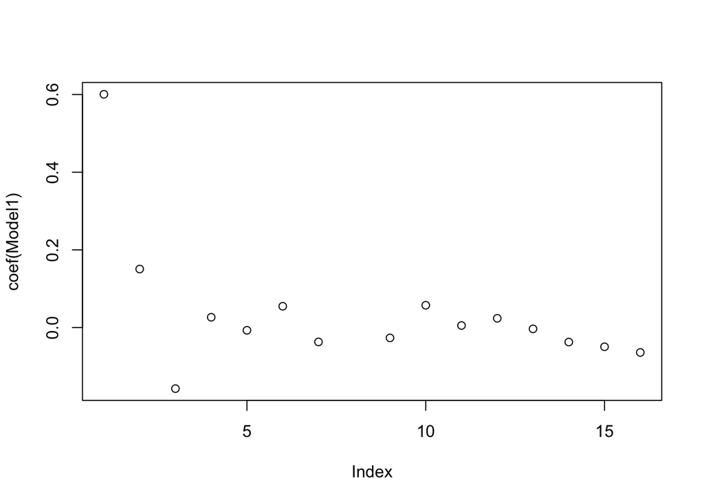

```r
plot(coef(Model1))
```

```r
#Logit Model:
Model1a<-glm(female ~ ASTHMAEV + CHEARTDIEV + HEARTCONEV + STROKEV + ARTHLIMIT + DIABETICAGE  + race_index + REGION + factor(educ_hs) + factor(educ_bach) + factor(educ_adv), family = binomial, data = newdata)
summary(Model1a)
```

```
##
## Call:
## glm(formula = female ~ ASTHMAEV + CHEARTDIEV + HEARTCONEV + STROKEV +
##     ARTHLIMIT + DIABETICAGE + race_index + REGION + factor(educ_hs) +
##     factor(educ_bach) + factor(educ_adv), family = binomial,
##     data = newdata)
##
## Deviance Residuals:
##     Min       1Q   Median       3Q      Max
## -1.9664  -1.2162   0.8219   1.0726   1.5966
##
## Coefficients:
##                    Estimate Std. Error z value Pr(>|z|)
## (Intercept)         0.41935    0.08538   4.911 9.04e-07 ***
## ASTHMAEV            0.66131    0.03957  16.711  < 2e-16 ***
## CHEARTDIEV         -0.65538    0.03941 -16.632  < 2e-16 ***
## HEARTCONEV          0.11181    0.03867   2.891 0.003836 **
## STROKEV            -0.03013    0.04876  -0.618 0.536540
## ARTHLIMIT           0.23220    0.03069   7.567 3.83e-14 ***
## DIABETICAGETRUE    -0.15540    0.03951  -3.933 8.37e-05 ***
## race_index1        -0.11335    0.06485  -1.748 0.080487 .
## race_index2         0.25133    0.07323   3.432 0.000599 ***
## REGIONMidwest       0.02398    0.04969   0.483 0.629363
## REGIONSouth         0.10107    0.04550   2.221 0.026325 *
## REGIONWest         -0.01355    0.05033  -0.269 0.787688
## factor(educ_hs)1   -0.16091    0.03706  -4.341 1.42e-05 ***
## factor(educ_bach)1 -0.20876    0.04945  -4.221 2.43e-05 ***
## factor(educ_adv)1  -0.26738    0.06618  -4.040 5.34e-05 ***
## ---
## Signif. codes:  0 '***' 0.001 '**' 0.01 '*' 0.05 '.' 0.1 ' ' 1
##
## (Dispersion parameter for binomial family taken to be 1)
##
##     Null deviance: 25886  on 18912  degrees of freedom
## Residual deviance: 25028  on 18898  degrees of freedom
##   (849563 observations deleted due to missingness)
## AIC: 25058
##
## Number of Fisher Scoring iterations: 4
```

```r
coeftest(Model1a)
```

```
##
## z test of coefficients:
##
##                     Estimate Std. Error  z value  Pr(>|z|)
## (Intercept)         0.419348   0.085382   4.9114 9.041e-07 ***
## ASTHMAEV            0.661309   0.039572  16.7115 < 2.2e-16 ***
## CHEARTDIEV         -0.655379   0.039405 -16.6319 < 2.2e-16 ***
## HEARTCONEV          0.111812   0.038671   2.8913  0.003836 **
## STROKEV            -0.030135   0.048758  -0.6181  0.536540
## ARTHLIMIT           0.232198   0.030688   7.5665 3.833e-14 ***
## DIABETICAGETRUE    -0.155401   0.039508  -3.9334 8.374e-05 ***
## race_index1        -0.113354   0.064853  -1.7479  0.080487 .
## race_index2         0.251333   0.073231   3.4321  0.000599 ***
## REGIONMidwest       0.023982   0.049690   0.4826  0.629363
## REGIONSouth         0.101067   0.045497   2.2214  0.026325 *
## REGIONWest         -0.013555   0.050331  -0.2693  0.787688
## factor(educ_hs)1   -0.160911   0.037064  -4.3414 1.416e-05 ***
## factor(educ_bach)1 -0.208757   0.049451  -4.2215 2.427e-05 ***
## factor(educ_adv)1  -0.267384   0.066179  -4.0403 5.338e-05 ***
## ---
## Signif. codes:  0 '***' 0.001 '**' 0.01 '*' 0.05 '.' 0.1 ' ' 1
```

```r
exp(Model1a$coefficients)
```

```
##        (Intercept)           ASTHMAEV         CHEARTDIEV
##          1.5209703          1.9373262          0.5192453
##         HEARTCONEV            STROKEV          ARTHLIMIT
##          1.1183025          0.9703146          1.2613699
##    DIABETICAGETRUE        race_index1        race_index2
##          0.8560721          0.8928348          1.2857382
##      REGIONMidwest        REGIONSouth         REGIONWest
##          1.0242716          1.1063513          0.9865367
##   factor(educ_hs)1 factor(educ_bach)1  factor(educ_adv)1
##          0.8513683          0.8115927          0.7653793
```

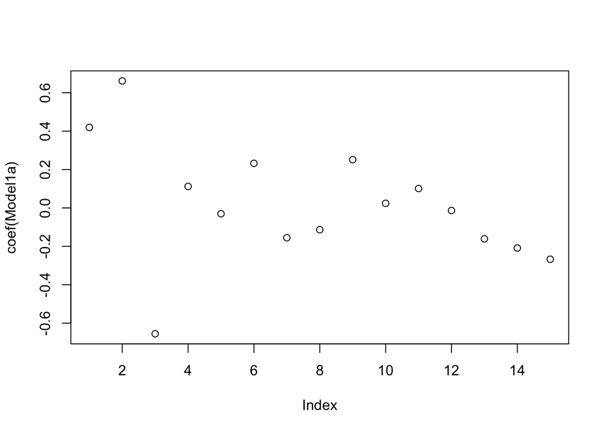

```r
plot(coef(Model1a))
```

```r
#Probit Model:
Model1b<-glm(female ~ ASTHMAEV + CHEARTDIEV + HEARTCONEV + STROKEV + ARTHLIMIT + DIABETICAGE + HEALTH + race_index + REGION + factor(educ_hs) + factor(educ_bach) + factor(educ_adv), family = binomial(link = "probit"), data = newdata)
summary(Model1b)
```

```
##
## Call:
## glm(formula = female ~ ASTHMAEV + CHEARTDIEV + HEARTCONEV + STROKEV +
##     ARTHLIMIT + DIABETICAGE + HEALTH + race_index + REGION +
##     factor(educ_hs) + factor(educ_bach) + factor(educ_adv), family = binomial(link = "probit"),
##     data = newdata)
##
## Deviance Residuals:
##    Min      1Q  Median      3Q     Max
## -1.996  -1.217   0.823   1.074   1.600
##
## Coefficients: (1 not defined because of singularities)
##                     Estimate Std. Error z value Pr(>|z|)
## (Intercept)         0.260752   0.052880   4.931 8.18e-07 ***
## ASTHMAEV            0.406160   0.024027  16.904  < 2e-16 ***
## CHEARTDIEV         -0.407943   0.024390 -16.726  < 2e-16 ***
## HEARTCONEV          0.070439   0.023867   2.951  0.00316 **
## STROKEV            -0.019193   0.030124  -0.637  0.52403
## ARTHLIMIT           0.144201   0.018996   7.591 3.18e-14 ***
## DIABETICAGETRUE    -0.096010   0.024433  -3.929 8.51e-05 ***
## HEALTHTRUE                NA         NA      NA       NA
## race_index1        -0.070617   0.040207  -1.756  0.07903 .
## race_index2         0.153024   0.045249   3.382  0.00072 ***
## REGIONMidwest       0.013118   0.030792   0.426  0.67009
## REGIONSouth         0.061763   0.028161   2.193  0.02829 *
## REGIONWest         -0.009474   0.031204  -0.304  0.76142
## factor(educ_hs)1   -0.098120   0.022856  -4.293 1.76e-05 ***
## factor(educ_bach)1 -0.128873   0.030731  -4.194 2.75e-05 ***
## factor(educ_adv)1  -0.166848   0.041140  -4.056 5.00e-05 ***
## ---
## Signif. codes:  0 '***' 0.001 '**' 0.01 '*' 0.05 '.' 0.1 ' ' 1
##
## (Dispersion parameter for binomial family taken to be 1)
##
##     Null deviance: 25874  on 18904  degrees of freedom
## Residual deviance: 25016  on 18890  degrees of freedom
##   (849571 observations deleted due to missingness)
## AIC: 25046
##
## Number of Fisher Scoring iterations: 4
```

```r
coeftest(Model1b)
```

```
##
## z test of coefficients:
##
##                      Estimate Std. Error  z value  Pr(>|z|)
## (Intercept)         0.2607518  0.0528804   4.9310 8.182e-07 ***
## ASTHMAEV            0.4061603  0.0240268  16.9045 < 2.2e-16 ***
## CHEARTDIEV         -0.4079427  0.0243902 -16.7257 < 2.2e-16 ***
## HEARTCONEV          0.0704388  0.0238666   2.9514 0.0031638 **
## STROKEV            -0.0191933  0.0301240  -0.6371 0.5240321
## ARTHLIMIT           0.1442008  0.0189964   7.5910 3.175e-14 ***
## DIABETICAGETRUE    -0.0960099  0.0244333  -3.9295 8.513e-05 ***
## HEALTHTRUE                 NA         NA       NA        NA
## race_index1        -0.0706167  0.0402066  -1.7563 0.0790297 .
## race_index2         0.1530242  0.0452491   3.3818 0.0007201 ***
## REGIONMidwest       0.0131181  0.0307922   0.4260 0.6700926
## REGIONSouth         0.0617630  0.0281611   2.1932 0.0282925 *
## REGIONWest         -0.0094742  0.0312042  -0.3036 0.7614188
## factor(educ_hs)1   -0.0981203  0.0228561  -4.2930 1.763e-05 ***
## factor(educ_bach)1 -0.1288727  0.0307309  -4.1936 2.746e-05 ***
## factor(educ_adv)1  -0.1668481  0.0411397  -4.0556 5.000e-05 ***
## ---
## Signif. codes:  0 '***' 0.001 '**' 0.01 '*' 0.05 '.' 0.1 ' ' 1
```

```r
exp(Model1b$coefficients)
```

```
##        (Intercept)           ASTHMAEV         CHEARTDIEV
##          1.2979055          1.5010432          0.6650170
##         HEARTCONEV            STROKEV          ARTHLIMIT
##          1.0729790          0.9809898          1.1551160
##    DIABETICAGETRUE         HEALTHTRUE        race_index1
##          0.9084551                 NA          0.9318190
##        race_index2      REGIONMidwest        REGIONSouth
##          1.1653532          1.0132046          1.0637102
##         REGIONWest   factor(educ_hs)1 factor(educ_bach)1
##          0.9905706          0.9065398          0.8790859
##  factor(educ_adv)1
##          0.8463281
```

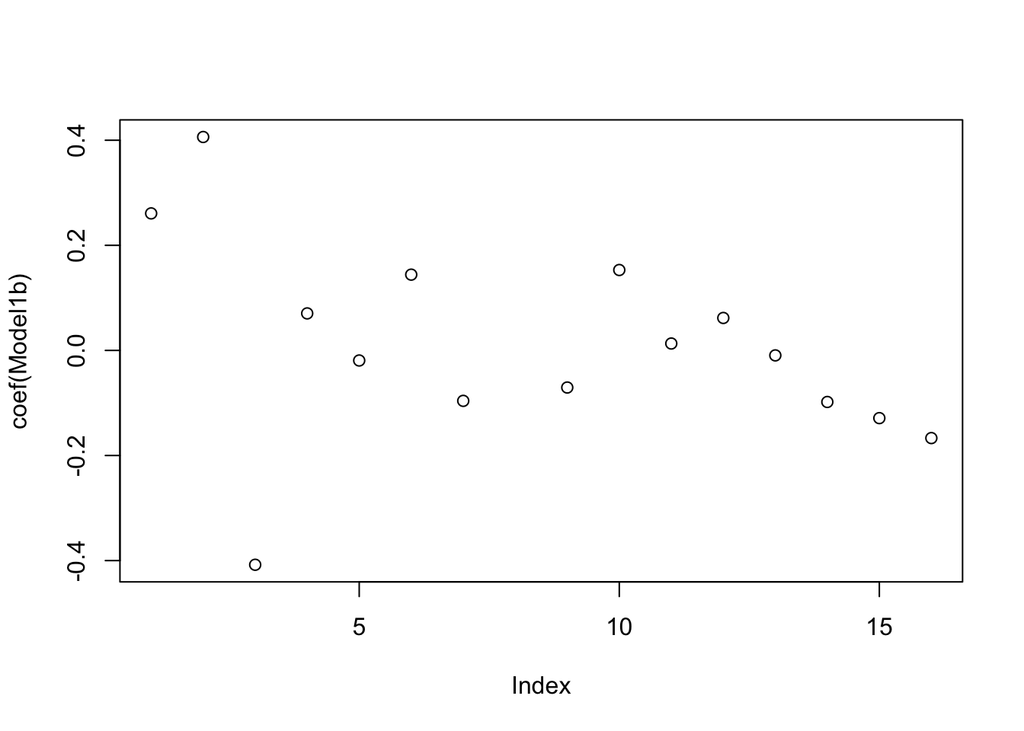

```r
plot(coef(Model1b))
```

```r
#Linear Model:
Model2<-lm(female ~ race_index + factor(educ_hs) + factor(educ_bach) + factor(educ_adv) + ASTHMAEV + CHEARTDIEV + HEARTCONEV + STROKEV + ARTHLIMIT + DIABETICAGE + HEALTH)
summary(Model2)
```

```
##
## Call:
## lm(formula = female ~ race_index + factor(educ_hs) + factor(educ_bach) +
##     factor(educ_adv) + ASTHMAEV + CHEARTDIEV + HEARTCONEV + STROKEV +
##     ARTHLIMIT + DIABETICAGE + HEALTH)
##
## Residuals:
##     Min      1Q  Median      3Q     Max
## -0.9058 -0.5140  0.2863  0.4364  0.7120
##
## Coefficients: (1 not defined because of singularities)
##                     Estimate Std. Error t value Pr(>|t|)
## (Intercept)         0.605331   0.017913  33.792  < 2e-16 ***
## race_index1        -0.021809   0.015048  -1.449   0.1473
## race_index2         0.068717   0.016592   4.142 3.46e-05 ***
## factor(educ_hs)1   -0.038540   0.008605  -4.479 7.55e-06 ***
## factor(educ_bach)1 -0.049640   0.011740  -4.228 2.37e-05 ***
## factor(educ_adv)1  -0.064034   0.015737  -4.069 4.74e-05 ***
## ASTHMAEV            0.150047   0.008879  16.898  < 2e-16 ***
## CHEARTDIEV         -0.156799   0.009271 -16.912  < 2e-16 ***
## HEARTCONEV          0.026854   0.009017   2.978   0.0029 **
## STROKEV            -0.006246   0.011410  -0.547   0.5841
## ARTHLIMIT           0.054851   0.007217   7.600 3.09e-14 ***
## DIABETICAGETRUE    -0.036182   0.009260  -3.907 9.36e-05 ***
## HEALTHTRUE                NA         NA      NA       NA
## ---
## Signif. codes:  0 '***' 0.001 '**' 0.01 '*' 0.05 '.' 0.1 ' ' 1
##
## Residual standard error: 0.4848 on 18893 degrees of freedom
##   (849571 observations deleted due to missingness)
## Multiple R-squared:  0.04378,    Adjusted R-squared:  0.04323
## F-statistic: 78.64 on 11 and 18893 DF,  p-value: < 2.2e-16
```

```r
coeftest(Model2)
```

```
##
## t test of coefficients:
##
##                      Estimate Std. Error  t value  Pr(>|t|)
## (Intercept)         0.6053311  0.0179132  33.7924 < 2.2e-16 ***
## race_index1        -0.0218086  0.0150477  -1.4493  0.147271
## race_index2         0.0687169  0.0165920   4.1416 3.464e-05 ***
## factor(educ_hs)1   -0.0385398  0.0086050  -4.4788 7.551e-06 ***
## factor(educ_bach)1 -0.0496397  0.0117404  -4.2281 2.368e-05 ***
## factor(educ_adv)1  -0.0640341  0.0157367  -4.0691 4.739e-05 ***
## ASTHMAEV            0.1500469  0.0088794  16.8984 < 2.2e-16 ***
## CHEARTDIEV         -0.1567988  0.0092713 -16.9122 < 2.2e-16 ***
## HEARTCONEV          0.0268542  0.0090171   2.9782  0.002904 **
## STROKEV            -0.0062463  0.0114097  -0.5474  0.584076
## ARTHLIMIT           0.0548505  0.0072170   7.6002 3.094e-14 ***
## DIABETICAGETRUE    -0.0361819  0.0092600  -3.9074 9.364e-05 ***
## HEALTHTRUE                 NA         NA       NA        NA
## ---
## Signif. codes:  0 '***' 0.001 '**' 0.01 '*' 0.05 '.' 0.1 ' ' 1
```

```r
exp(Model2$coefficients)
```

```
##        (Intercept)        race_index1        race_index2
##          1.8318587          0.9784275          1.0711329
##   factor(educ_hs)1 factor(educ_bach)1  factor(educ_adv)1
##          0.9621934          0.9515722          0.9379730
##           ASTHMAEV         CHEARTDIEV         HEARTCONEV
##          1.1618888          0.8548760          1.0272180
##            STROKEV          ARTHLIMIT    DIABETICAGETRUE
##          0.9937732          1.0563827          0.9644648
##         HEALTHTRUE
##                 NA
```

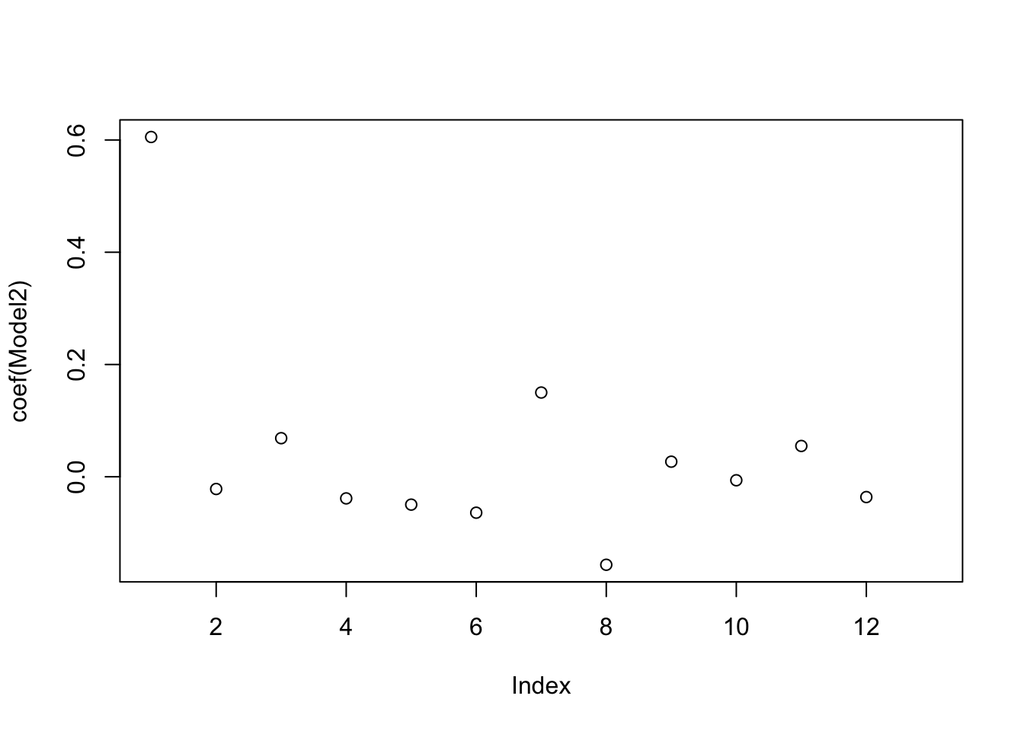

```r
plot(coef(Model2))
```

```r
#Logit Model:
Model2a<-glm(female ~ race_index + factor(educ_hs) + factor(educ_bach) + factor(educ_adv) + ASTHMAEV + CHEARTDIEV + HEARTCONEV + STROKEV + ARTHLIMIT + DIABETICAGE + HEALTH,family = binomial, data = newdata)
summary(Model2a)
```

```
##
## Call:
## glm(formula = female ~ race_index + factor(educ_hs) + factor(educ_bach) +
##     factor(educ_adv) + ASTHMAEV + CHEARTDIEV + HEARTCONEV + STROKEV +
##     ARTHLIMIT + DIABETICAGE + HEALTH, family = binomial, data = newdata)
##
## Deviance Residuals:
##     Min       1Q   Median       3Q      Max
## -1.9522  -1.1999   0.8198   1.0691   1.5732
##
## Coefficients: (1 not defined because of singularities)
##                    Estimate Std. Error z value Pr(>|z|)
## (Intercept)         0.43719    0.07623   5.735 9.76e-09 ***
## race_index1        -0.09062    0.06379  -1.421 0.155443
## race_index2         0.30181    0.07097   4.252 2.11e-05 ***
## factor(educ_hs)1   -0.16576    0.03696  -4.485 7.28e-06 ***
## factor(educ_bach)1 -0.20723    0.04946  -4.190 2.79e-05 ***
## factor(educ_adv)1  -0.26727    0.06616  -4.039 5.36e-05 ***
## ASTHMAEV            0.65781    0.03955  16.633  < 2e-16 ***
## CHEARTDIEV         -0.65530    0.03939 -16.635  < 2e-16 ***
## HEARTCONEV          0.11529    0.03867   2.981 0.002869 **
## STROKEV            -0.02733    0.04873  -0.561 0.574908
## ARTHLIMIT           0.23233    0.03068   7.572 3.67e-14 ***
## DIABETICAGETRUE    -0.15303    0.03949  -3.875 0.000107 ***
## HEALTHTRUE               NA         NA      NA       NA
## ---
## Signif. codes:  0 '***' 0.001 '**' 0.01 '*' 0.05 '.' 0.1 ' ' 1
##
## (Dispersion parameter for binomial family taken to be 1)
##
##     Null deviance: 25874  on 18904  degrees of freedom
## Residual deviance: 25025  on 18893  degrees of freedom
##   (849571 observations deleted due to missingness)
## AIC: 25049
##
## Number of Fisher Scoring iterations: 4
```

```r
coeftest(Model2a)
```

```
##
## z test of coefficients:
##
##                     Estimate Std. Error  z value  Pr(>|z|)
## (Intercept)         0.437190   0.076233   5.7349 9.757e-09 ***
## race_index1        -0.090624   0.063794  -1.4206 0.1554427
## race_index2         0.301807   0.070972   4.2525 2.114e-05 ***
## factor(educ_hs)1   -0.165764   0.036958  -4.4852 7.284e-06 ***
## factor(educ_bach)1 -0.207229   0.049457  -4.1901 2.789e-05 ***
## factor(educ_adv)1  -0.267266   0.066164  -4.0394 5.358e-05 ***
## ASTHMAEV            0.657811   0.039549  16.6326 < 2.2e-16 ***
## CHEARTDIEV         -0.655303   0.039394 -16.6347 < 2.2e-16 ***
## HEARTCONEV          0.115287   0.038668   2.9815 0.0028688 **
## STROKEV            -0.027330   0.048730  -0.5608 0.5749081
## ARTHLIMIT           0.232328   0.030682   7.5722 3.668e-14 ***
## DIABETICAGETRUE    -0.153034   0.039494  -3.8749 0.0001067 ***
## HEALTHTRUE                NA         NA       NA        NA
## ---
## Signif. codes:  0 '***' 0.001 '**' 0.01 '*' 0.05 '.' 0.1 ' ' 1
```

```r
exp(Model2a$coefficients)
```

```
##        (Intercept)        race_index1        race_index2
##          1.5483495          0.9133608          1.3522997
##   factor(educ_hs)1 factor(educ_bach)1  factor(educ_adv)1
##          0.8472461          0.8128337          0.7654691
##           ASTHMAEV         CHEARTDIEV         HEARTCONEV
##          1.9305621          0.5192848          1.1221959
##            STROKEV          ARTHLIMIT    DIABETICAGETRUE
##          0.9730404          1.2615338          0.8581002
##         HEALTHTRUE
##                 NA
```

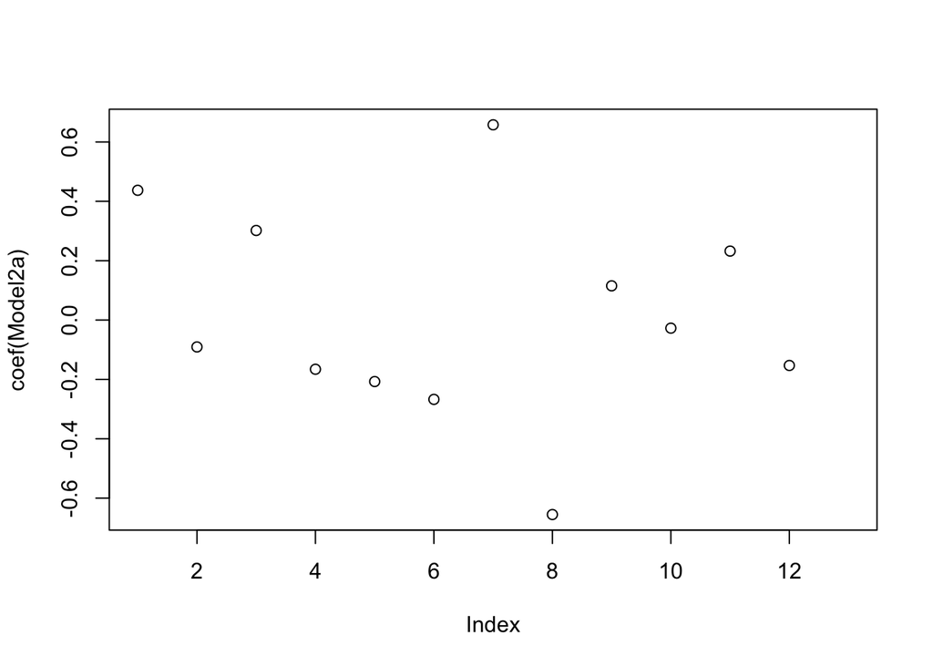

```r
plot(coef(Model2a))
```

```r
#Probit Model:
Model2b<-glm(female ~ race_index + factor(educ_hs) + factor(educ_bach) + factor(educ_adv) + ASTHMAEV + CHEARTDIEV + HEARTCONEV + STROKEV + ARTHLIMIT + DIABETICAGE + HEALTH, family = binomial(link = "probit"), data = newdata)
summary(Model2b)
```

```
##
## Call:
## glm(formula = female ~ race_index + factor(educ_hs) + factor(educ_bach) +
##     factor(educ_adv) + ASTHMAEV + CHEARTDIEV + HEARTCONEV + STROKEV +
##     ARTHLIMIT + DIABETICAGE + HEALTH, family = binomial(link = "probit"),
##     data = newdata)
##
## Deviance Residuals:
##     Min       1Q   Median       3Q      Max
## -1.9783  -1.2001   0.8197   1.0692   1.5745
##
## Coefficients: (1 not defined because of singularities)
##                    Estimate Std. Error z value Pr(>|z|)
## (Intercept)         0.27227    0.04717   5.772 7.83e-09 ***
## race_index1        -0.05806    0.03954  -1.468 0.141980
## race_index2         0.18250    0.04382   4.164 3.12e-05 ***
## factor(educ_hs)1   -0.10167    0.02279  -4.462 8.12e-06 ***
## factor(educ_bach)1 -0.12927    0.03072  -4.208 2.58e-05 ***
## factor(educ_adv)1  -0.16649    0.04113  -4.048 5.17e-05 ***
## ASTHMAEV            0.40438    0.02401  16.840  < 2e-16 ***
## CHEARTDIEV         -0.40685    0.02438 -16.689  < 2e-16 ***
## HEARTCONEV          0.07121    0.02385   2.985 0.002832 **
## STROKEV            -0.01716    0.03011  -0.570 0.568622
## ARTHLIMIT           0.14414    0.01899   7.591 3.18e-14 ***
## DIABETICAGETRUE    -0.09404    0.02442  -3.852 0.000117 ***
## HEALTHTRUE               NA         NA      NA       NA
## ---
## Signif. codes:  0 '***' 0.001 '**' 0.01 '*' 0.05 '.' 0.1 ' ' 1
##
## (Dispersion parameter for binomial family taken to be 1)
##
##     Null deviance: 25874  on 18904  degrees of freedom
## Residual deviance: 25026  on 18893  degrees of freedom
##   (849571 observations deleted due to missingness)
## AIC: 25050
##
## Number of Fisher Scoring iterations: 4
```

```r
coeftest(Model2b)
```

```
##
## z test of coefficients:
##
##                     Estimate Std. Error  z value  Pr(>|z|)
## (Intercept)         0.272265   0.047169   5.7721 7.828e-09 ***
## race_index1        -0.058056   0.039535  -1.4685 0.1419799
## race_index2         0.182495   0.043824   4.1643 3.123e-05 ***
## factor(educ_hs)1   -0.101671   0.022785  -4.4621 8.115e-06 ***
## factor(educ_bach)1 -0.129271   0.030723  -4.2077 2.580e-05 ***
## factor(educ_adv)1  -0.166489   0.041133  -4.0476 5.174e-05 ***
## ASTHMAEV            0.404382   0.024013  16.8402 < 2.2e-16 ***
## CHEARTDIEV         -0.406847   0.024378 -16.6888 < 2.2e-16 ***
## HEARTCONEV          0.071213   0.023854   2.9854 0.0028322 **
## STROKEV            -0.017164   0.030109  -0.5701 0.5686219
## ARTHLIMIT           0.144143   0.018989   7.5909 3.178e-14 ***
## DIABETICAGETRUE    -0.094039   0.024416  -3.8516 0.0001174 ***
## HEALTHTRUE                NA         NA       NA        NA
## ---
## Signif. codes:  0 '***' 0.001 '**' 0.01 '*' 0.05 '.' 0.1 ' ' 1
```

```r
exp(Model2b$coefficients)
```

```
##        (Intercept)        race_index1        race_index2
##          1.3129353          0.9435972          1.2002082
##   factor(educ_hs)1 factor(educ_bach)1  factor(educ_adv)1
##          0.9033268          0.8787360          0.8466317
##           ASTHMAEV         CHEARTDIEV         HEARTCONEV
##          1.4983768          0.6657459          1.0738099
##            STROKEV          ARTHLIMIT    DIABETICAGETRUE
##          0.9829821          1.1550488          0.9102469
##         HEALTHTRUE
##                 NA
```

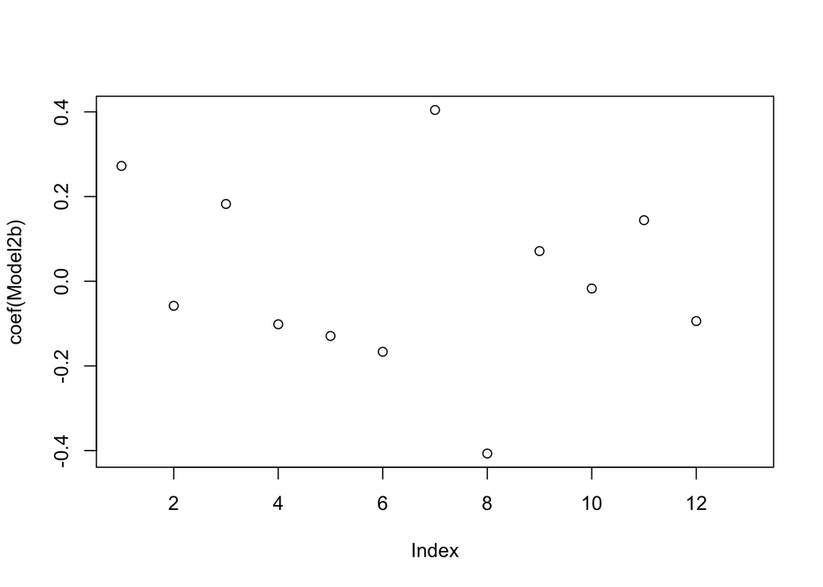

```r
plot(coef(Model2b))
```

```r
#Linear Model:
Model3<-lm(female ~ factor(race_index) + factor(educ_hs) + factor(educ_bach) + factor(educ_adv) + ASTHMAEV + CHEARTDIEV + HEARTCONEV + STROKEV + ARTHLIMIT + DIABETICAGE + CIGSDAY + HRSLEEP + VISITYRNO + BMI + factor(REGION))
summary(Model3)
```

```
##
## Call:
## lm(formula = female ~ factor(race_index) + factor(educ_hs) +
##     factor(educ_bach) + factor(educ_adv) + ASTHMAEV + CHEARTDIEV +
##     HEARTCONEV + STROKEV + ARTHLIMIT + DIABETICAGE + CIGSDAY +
##     HRSLEEP + VISITYRNO + BMI + factor(REGION))
##
## Residuals:
##     Min      1Q  Median      3Q     Max
## -1.1100 -0.4831  0.2229  0.4486  0.7901
##
## Coefficients:
##                         Estimate Std. Error t value Pr(>|t|)
## (Intercept)            0.3335700  0.0674098   4.948 7.95e-07 ***
## factor(race_index)1    0.0154117  0.0419955   0.367  0.71366
## factor(race_index)2   -0.0054699  0.0459836  -0.119  0.90532
## factor(educ_hs)1      -0.0037681  0.0217617  -0.173  0.86254
## factor(educ_bach)1    -0.0651618  0.0390111  -1.670  0.09497 .
## factor(educ_adv)1     -0.1958389  0.0635257  -3.083  0.00207 **
## ASTHMAEV               0.1867393  0.0215808   8.653  < 2e-16 ***
## CHEARTDIEV            -0.1226342  0.0249264  -4.920 9.19e-07 ***
## HEARTCONEV             0.0322577  0.0245256   1.315  0.18853
## STROKEV                0.0053127  0.0294460   0.180  0.85684
## ARTHLIMIT              0.0074664  0.0195440   0.382  0.70247
## DIABETICAGETRUE       -0.0272498  0.0339742  -0.802  0.42258
## CIGSDAYTRUE            0.1056653  0.0193308   5.466 5.03e-08 ***
## HRSLEEPTRUE           -0.0336047  0.0195213  -1.721  0.08529 .
## VISITYRNOTRUE         -0.0304903  0.0192526  -1.584  0.11338
## BMI                    0.0041458  0.0007294   5.684 1.46e-08 ***
## factor(REGION)Midwest  0.0270910  0.0312101   0.868  0.38546
## factor(REGION)South    0.0776601  0.0290657   2.672  0.00759 **
## factor(REGION)West    -0.0352832  0.0334513  -1.055  0.29163
## ---
## Signif. codes:  0 '***' 0.001 '**' 0.01 '*' 0.05 '.' 0.1 ' ' 1
##
## Residual standard error: 0.4815 on 2659 degrees of freedom
##   (865798 observations deleted due to missingness)
## Multiple R-squared:  0.07346,    Adjusted R-squared:  0.06719
## F-statistic: 11.71 on 18 and 2659 DF,  p-value: < 2.2e-16
```

```r
coeftest(Model3)
```

```
##
## t test of coefficients:
##
##                          Estimate  Std. Error t value  Pr(>|t|)
## (Intercept)            0.33357001  0.06740976  4.9484 7.950e-07 ***
## factor(race_index)1    0.01541169  0.04199548  0.3670  0.713660
## factor(race_index)2   -0.00546992  0.04598355 -0.1190  0.905321
## factor(educ_hs)1      -0.00376813  0.02176173 -0.1732  0.862544
## factor(educ_bach)1    -0.06516180  0.03901108 -1.6703  0.094970 .
## factor(educ_adv)1     -0.19583894  0.06352566 -3.0828  0.002071 **
## ASTHMAEV               0.18673925  0.02158083  8.6530 < 2.2e-16 ***
## CHEARTDIEV            -0.12263422  0.02492638 -4.9199 9.189e-07 ***
## HEARTCONEV             0.03225768  0.02452558  1.3153  0.188534
## STROKEV                0.00531270  0.02944597  0.1804  0.856835
## ARTHLIMIT              0.00746644  0.01954402  0.3820  0.702468
## DIABETICAGETRUE       -0.02724977  0.03397423 -0.8021  0.422583
## CIGSDAYTRUE            0.10566530  0.01933079  5.4662 5.026e-08 ***
## HRSLEEPTRUE           -0.03360474  0.01952127 -1.7214  0.085287 .
## VISITYRNOTRUE         -0.03049030  0.01925261 -1.5837  0.113382
## BMI                    0.00414583  0.00072939  5.6840 1.459e-08 ***
## factor(REGION)Midwest  0.02709104  0.03121006  0.8680  0.385460
## factor(REGION)South    0.07766012  0.02906568  2.6719  0.007589 **
## factor(REGION)West    -0.03528322  0.03345130 -1.0548  0.291629
## ---
## Signif. codes:  0 '***' 0.001 '**' 0.01 '*' 0.05 '.' 0.1 ' ' 1
```

```r
exp(Model3$coefficients)
```

```
##           (Intercept)   factor(race_index)1   factor(race_index)2
##             1.3959428             1.0155311             0.9945450
##      factor(educ_hs)1    factor(educ_bach)1     factor(educ_adv)1
##             0.9962390             0.9369159             0.8221446
##              ASTHMAEV            CHEARTDIEV            HEARTCONEV
##             1.2053130             0.8845872             1.0327836
##               STROKEV             ARTHLIMIT       DIABETICAGETRUE
##             1.0053268             1.0074944             0.9731182
##           CIGSDAYTRUE           HRSLEEPTRUE         VISITYRNOTRUE
##             1.1114498             0.9669536             0.9699698
##                   BMI factor(REGION)Midwest   factor(REGION)South
##             1.0041544             1.0274613             1.0807553
##    factor(REGION)West
##             0.9653320
```

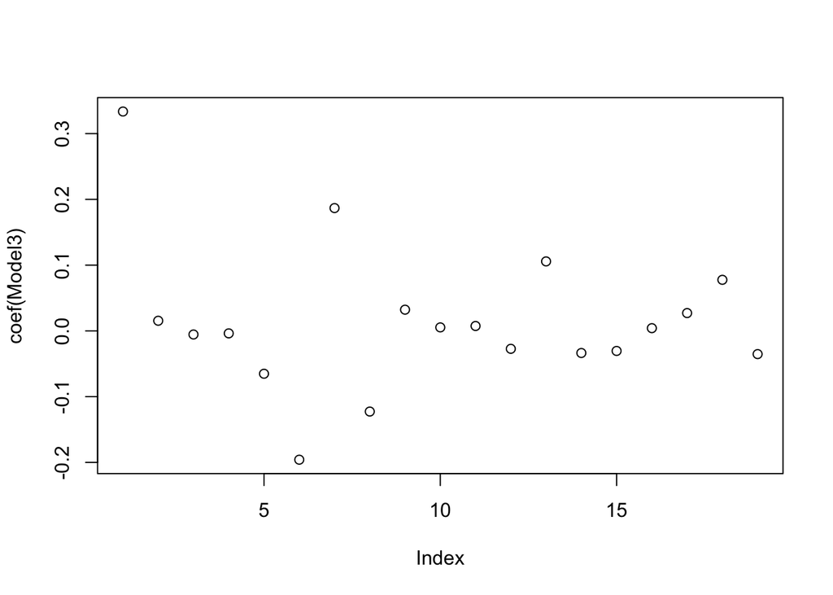

```r
plot(coef(Model3))
```

```r
#Logit Model:
Model3a<-glm(female ~ factor(race_index) + factor(educ_hs) + factor(educ_bach) + factor(educ_adv) + ASTHMAEV + CHEARTDIEV + HEARTCONEV + STROKEV + ARTHLIMIT + DIABETICAGE + CIGSDAY + HRSLEEP + VISITYRNO + BMI, family = binomial, data = newdata)
summary(Model3a)
```

```
##
## Call:
## glm(formula = female ~ factor(race_index) + factor(educ_hs) +
##     factor(educ_bach) + factor(educ_adv) + ASTHMAEV + CHEARTDIEV +
##     HEARTCONEV + STROKEV + ARTHLIMIT + DIABETICAGE + CIGSDAY +
##     HRSLEEP + VISITYRNO + BMI, family = binomial, data = newdata)
##
## Deviance Residuals:
##    Min      1Q  Median      3Q     Max
## -2.269  -1.144   0.739   1.094   1.714
##
## Coefficients:
##                      Estimate Std. Error z value Pr(>|z|)
## (Intercept)         -0.719230   0.271851  -2.646  0.00815 **
## factor(race_index)1  0.154702   0.178478   0.867  0.38606
## factor(race_index)2  0.139126   0.193342   0.720  0.47178
## factor(educ_hs)1    -0.037337   0.093462  -0.399  0.68954
## factor(educ_bach)1  -0.268080   0.166924  -1.606  0.10827
## factor(educ_adv)1   -0.898691   0.291156  -3.087  0.00202 **
## ASTHMAEV             0.786976   0.095928   8.204 2.33e-16 ***
## CHEARTDIEV          -0.507612   0.107790  -4.709 2.49e-06 ***
## HEARTCONEV           0.151725   0.106618   1.423  0.15472
## STROKEV              0.049505   0.127084   0.390  0.69687
## ARTHLIMIT            0.034824   0.084064   0.414  0.67869
## DIABETICAGETRUE     -0.120963   0.146210  -0.827  0.40805
## CIGSDAYTRUE          0.433648   0.083323   5.204 1.95e-07 ***
## HRSLEEPTRUE         -0.137939   0.084240  -1.637  0.10153
## VISITYRNOTRUE       -0.108964   0.082746  -1.317  0.18789
## BMI                  0.019616   0.003594   5.459 4.80e-08 ***
## ---
## Signif. codes:  0 '***' 0.001 '**' 0.01 '*' 0.05 '.' 0.1 ' ' 1
##
## (Dispersion parameter for binomial family taken to be 1)
##
##     Null deviance: 3695.7  on 2677  degrees of freedom
## Residual deviance: 3509.7  on 2662  degrees of freedom
##   (865798 observations deleted due to missingness)
## AIC: 3541.7
##
## Number of Fisher Scoring iterations: 4
```

```r
coeftest(Model3a)
```

```
##
## z test of coefficients:
##
##                       Estimate Std. Error z value  Pr(>|z|)
## (Intercept)         -0.7192301  0.2718512 -2.6457  0.008153 **
## factor(race_index)1  0.1547025  0.1784780  0.8668  0.386058
## factor(race_index)2  0.1391255  0.1933419  0.7196  0.471782
## factor(educ_hs)1    -0.0373368  0.0934623 -0.3995  0.689536
## factor(educ_bach)1  -0.2680805  0.1669236 -1.6060  0.108272
## factor(educ_adv)1   -0.8986907  0.2911565 -3.0866  0.002024 **
## ASTHMAEV             0.7869764  0.0959285  8.2038 2.329e-16 ***
## CHEARTDIEV          -0.5076119  0.1077904 -4.7092 2.486e-06 ***
## HEARTCONEV           0.1517253  0.1066184  1.4231  0.154716
## STROKEV              0.0495046  0.1270839  0.3895  0.696875
## ARTHLIMIT            0.0348236  0.0840644  0.4142  0.678692
## DIABETICAGETRUE     -0.1209633  0.1462096 -0.8273  0.408051
## CIGSDAYTRUE          0.4336482  0.0833232  5.2044 1.946e-07 ***
## HRSLEEPTRUE         -0.1379394  0.0842396 -1.6375  0.101533
## VISITYRNOTRUE       -0.1089636  0.0827463 -1.3168  0.187892
## BMI                  0.0196165  0.0035937  5.4585 4.801e-08 ***
## ---
## Signif. codes:  0 '***' 0.001 '**' 0.01 '*' 0.05 '.' 0.1 ' ' 1
```

```r
exp(Model3a$coefficients)
```

```
##         (Intercept) factor(race_index)1 factor(race_index)2
##           0.4871271           1.1673106           1.1492683
##    factor(educ_hs)1  factor(educ_bach)1   factor(educ_adv)1
##           0.9633516           0.7648462           0.4071023
##            ASTHMAEV          CHEARTDIEV          HEARTCONEV
##           2.1967443           0.6019313           1.1638405
##             STROKEV           ARTHLIMIT     DIABETICAGETRUE
##           1.0507505           1.0354370           0.8860665
##         CIGSDAYTRUE         HRSLEEPTRUE       VISITYRNOTRUE
##           1.5428760           0.8711515           0.8967631
##                 BMI
##           1.0198102
```

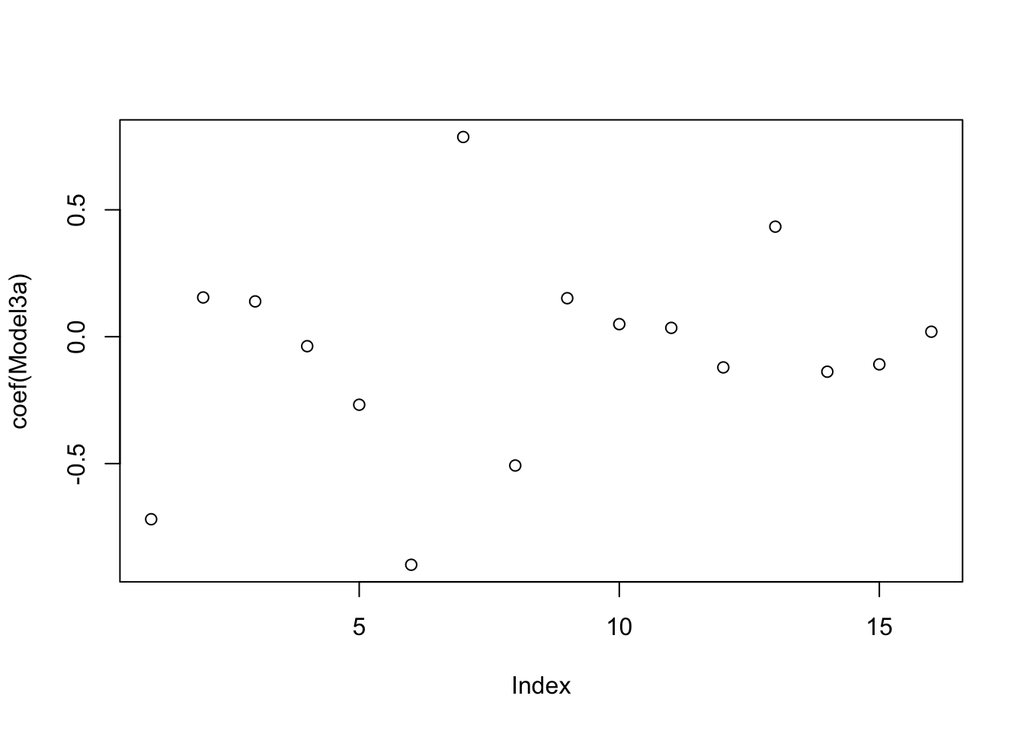

```r
plot(coef(Model3a))
```

```r
#Probit Model:
Model3b<-glm(female ~ factor(race_index) + factor(educ_hs) + factor(educ_bach) + factor(educ_adv) + ASTHMAEV + CHEARTDIEV + HEARTCONEV + STROKEV + ARTHLIMIT + DIABETICAGE + CIGSDAY + HRSLEEP + VISITYRNO + BMI, family = binomial(link = "probit"), data = newdata)
summary(Model3b)
```

```
##
## Call:
## glm(formula = female ~ factor(race_index) + factor(educ_hs) +
##     factor(educ_bach) + factor(educ_adv) + ASTHMAEV + CHEARTDIEV +
##     HEARTCONEV + STROKEV + ARTHLIMIT + DIABETICAGE + CIGSDAY +
##     HRSLEEP + VISITYRNO + BMI, family = binomial(link = "probit"),
##     data = newdata)
##
## Deviance Residuals:
##    Min      1Q  Median      3Q     Max
## -2.341  -1.143   0.739   1.095   1.723
##
## Coefficients:
##                      Estimate Std. Error z value Pr(>|z|)
## (Intercept)         -0.435696   0.167120  -2.607  0.00913 **
## factor(race_index)1  0.093060   0.110182   0.845  0.39833
## factor(race_index)2  0.083782   0.119362   0.702  0.48273
## factor(educ_hs)1    -0.023132   0.057710  -0.401  0.68855
## factor(educ_bach)1  -0.167157   0.103317  -1.618  0.10568
## factor(educ_adv)1   -0.559890   0.175512  -3.190  0.00142 **
## ASTHMAEV             0.482157   0.058406   8.255  < 2e-16 ***
## CHEARTDIEV          -0.313876   0.066403  -4.727 2.28e-06 ***
## HEARTCONEV           0.093559   0.065619   1.426  0.15392
## STROKEV              0.031290   0.078377   0.399  0.68973
## ARTHLIMIT            0.020367   0.051934   0.392  0.69493
## DIABETICAGETRUE     -0.073837   0.090327  -0.817  0.41368
## CIGSDAYTRUE          0.267016   0.051392   5.196 2.04e-07 ***
## HRSLEEPTRUE         -0.082617   0.051986  -1.589  0.11201
## VISITYRNOTRUE       -0.065942   0.051093  -1.291  0.19683
## BMI                  0.011875   0.002117   5.609 2.04e-08 ***
## ---
## Signif. codes:  0 '***' 0.001 '**' 0.01 '*' 0.05 '.' 0.1 ' ' 1
##
## (Dispersion parameter for binomial family taken to be 1)
##
##     Null deviance: 3695.7  on 2677  degrees of freedom
## Residual deviance: 3510.2  on 2662  degrees of freedom
##   (865798 observations deleted due to missingness)
## AIC: 3542.2
##
## Number of Fisher Scoring iterations: 4
```

```r
coeftest(Model3b)
```

```
##
## z test of coefficients:
##
##                       Estimate Std. Error z value  Pr(>|z|)
## (Intercept)         -0.4356962  0.1671201 -2.6071  0.009132 **
## factor(race_index)1  0.0930598  0.1101816  0.8446  0.398332
## factor(race_index)2  0.0837821  0.1193621  0.7019  0.482732
## factor(educ_hs)1    -0.0231319  0.0577102 -0.4008  0.688546
## factor(educ_bach)1  -0.1671571  0.1033167 -1.6179  0.105682
## factor(educ_adv)1   -0.5598905  0.1755117 -3.1900  0.001423 **
## ASTHMAEV             0.4821574  0.0584060  8.2553 < 2.2e-16 ***
## CHEARTDIEV          -0.3138756  0.0664026 -4.7269 2.280e-06 ***
## HEARTCONEV           0.0935594  0.0656185  1.4258  0.153924
## STROKEV              0.0312900  0.0783772  0.3992  0.689729
## ARTHLIMIT            0.0203675  0.0519340  0.3922  0.694925
## DIABETICAGETRUE     -0.0738367  0.0903274 -0.8174  0.413680
## CIGSDAYTRUE          0.2670160  0.0513922  5.1957 2.040e-07 ***
## HRSLEEPTRUE         -0.0826173  0.0519858 -1.5892  0.112009
## VISITYRNOTRUE       -0.0659422  0.0510928 -1.2906  0.196830
## BMI                  0.0118752  0.0021173  5.6087 2.039e-08 ***
## ---
## Signif. codes:  0 '***' 0.001 '**' 0.01 '*' 0.05 '.' 0.1 ' ' 1
```

```r
exp(Model3b$coefficients)
```

```
##         (Intercept) factor(race_index)1 factor(race_index)2
##           0.6468142           1.0975274           1.0873920
##    factor(educ_hs)1  factor(educ_bach)1   factor(educ_adv)1
##           0.9771335           0.8460667           0.5712716
##            ASTHMAEV          CHEARTDIEV          HEARTCONEV
##           1.6195648           0.7306099           1.0980758
##             STROKEV           ARTHLIMIT     DIABETICAGETRUE
##           1.0317847           1.0205763           0.9288234
##         CIGSDAYTRUE         HRSLEEPTRUE       VISITYRNOTRUE
##           1.3060613           0.9207034           0.9361850
##                 BMI
##           1.0119460
```

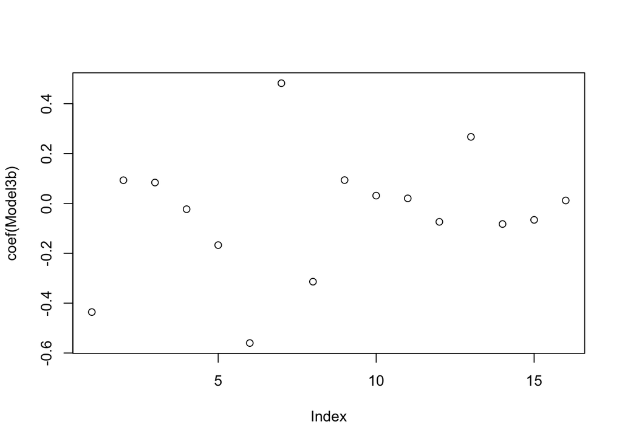

```r
plot(coef(Model3b))
```

#ANOVA TEST:

```r
#MODEL 1 ANOVA:
anova(Model1)
```

```
## Analysis of Variance Table
##
## Response: female
##                      Df Sum Sq Mean Sq  F value    Pr(>F)
## ASTHMAEV              1   75.7  75.661 322.0871 < 2.2e-16 ***
## CHEARTDIEV            1   60.8  60.773 258.7078 < 2.2e-16 ***
## HEARTCONEV            1    2.8   2.769  11.7864 0.0005979 ***
## STROKEV               1    0.3   0.257   1.0927 0.2958761
## ARTHLIMIT             1   18.0  17.995  76.6033 < 2.2e-16 ***
## DIABETICAGE           1    3.6   3.553  15.1234 0.0001010 ***
## race_index            2   26.7  13.357  56.8588 < 2.2e-16 ***
## REGION                3    2.9   0.967   4.1177 0.0062770 **
## factor(educ_hs)       1    7.8   7.840  33.3767 7.712e-09 ***
## factor(educ_bach)     1    3.3   3.340  14.2195 0.0001632 ***
## factor(educ_adv)      1    3.9   3.897  16.5901 4.658e-05 ***
## Residuals         18890 4437.4   0.235
## ---
## Signif. codes:  0 '***' 0.001 '**' 0.01 '*' 0.05 '.' 0.1 ' ' 1
```

```r
anova(Model1a)
```

```
## Analysis of Deviance Table
##
## Model: binomial, link: logit
##
## Response: female
##
## Terms added sequentially (first to last)
##
##
##                   Df Deviance Resid. Df Resid. Dev
## NULL                              18912      25886
## ASTHMAEV           1   316.84     18911      25569
## CHEARTDIEV         1   249.02     18910      25320
## HEARTCONEV         1    11.27     18909      25309
## STROKEV            1     1.08     18908      25308
## ARTHLIMIT          1    75.41     18907      25233
## DIABETICAGE        1    14.66     18906      25218
## race_index         2   113.84     18904      25104
## REGION             3    12.07     18901      25092
## factor(educ_hs)    1    33.82     18900      25058
## factor(educ_bach)  1    14.25     18899      25044
## factor(educ_adv)   1    16.30     18898      25028
```

```r
anova(Model1b)
```

```
## Analysis of Deviance Table
##
## Model: binomial, link: probit
##
## Response: female
##
## Terms added sequentially (first to last)
##
##
##                   Df Deviance Resid. Df Resid. Dev
## NULL                              18904      25874
## ASTHMAEV           1   316.48     18903      25558
## CHEARTDIEV         1   249.59     18902      25308
## HEARTCONEV         1    11.69     18901      25297
## STROKEV            1     1.11     18900      25296
## ARTHLIMIT          1    76.15     18899      25219
## DIABETICAGE        1    14.64     18898      25205
## HEALTH             0     0.00     18898      25205
## race_index         2   113.23     18896      25092
## REGION             3    12.17     18893      25079
## factor(educ_hs)    1    33.11     18892      25046
## factor(educ_bach)  1    14.04     18891      25032
## factor(educ_adv)   1    16.35     18890      25016
```

```r
#MODEL 2 ANOVA:
anova(Model2)
```

```
## Analysis of Variance Table
##
## Response: female
##                      Df Sum Sq Mean Sq  F value    Pr(>F)
## race_index            2   32.2  16.116  68.5783 < 2.2e-16 ***
## factor(educ_hs)       1    8.6   8.577  36.4961 1.558e-09 ***
## factor(educ_bach)     1    3.8   3.752  15.9679 6.467e-05 ***
## factor(educ_adv)      1    4.1   4.059  17.2714 3.255e-05 ***
## ASTHMAEV              1   73.2  73.222 311.5840 < 2.2e-16 ***
## CHEARTDIEV            1   61.3  61.271 260.7264 < 2.2e-16 ***
## HEARTCONEV            1    3.5   3.454  14.6962 0.0001267 ***
## STROKEV               1    0.0   0.004   0.0157 0.9003129
## ARTHLIMIT             1   13.1  13.137  55.9008 7.955e-14 ***
## DIABETICAGE           1    3.6   3.588  15.2674 9.364e-05 ***
## Residuals         18893 4439.8   0.235
## ---
## Signif. codes:  0 '***' 0.001 '**' 0.01 '*' 0.05 '.' 0.1 ' ' 1
```

```r
anova(Model2a)
```

```
## Analysis of Deviance Table
##
## Model: binomial, link: logit
##
## Response: female
##
## Terms added sequentially (first to last)
##
##
##                   Df Deviance Resid. Df Resid. Dev
## NULL                              18904      25874
## race_index         2  133.258     18902      25741
## factor(educ_hs)    1   35.450     18901      25706
## factor(educ_bach)  1   15.145     18900      25691
## factor(educ_adv)   1   16.403     18899      25674
## ASTHMAEV           1  309.726     18898      25364
## CHEARTDIEV         1  253.954     18897      25110
## HEARTCONEV         1   14.720     18896      25096
## STROKEV            1    0.013     18895      25096
## ARTHLIMIT          1   55.583     18894      25040
## DIABETICAGE        1   15.090     18893      25025
## HEALTH             0    0.000     18893      25025
```

```r
anova(Model2b)
```

```
## Analysis of Deviance Table
##
## Model: binomial, link: probit
##
## Response: female
##
## Terms added sequentially (first to last)
##
##
##                   Df Deviance Resid. Df Resid. Dev
## NULL                              18904      25874
## race_index         2  133.258     18902      25741
## factor(educ_hs)    1   35.471     18901      25706
## factor(educ_bach)  1   15.149     18900      25691
## factor(educ_adv)   1   16.361     18899      25674
## ASTHMAEV           1  309.538     18898      25365
## CHEARTDIEV         1  253.427     18897      25111
## HEARTCONEV         1   14.608     18896      25097
## STROKEV            1    0.014     18895      25097
## ARTHLIMIT          1   55.794     18894      25041
## DIABETICAGE        1   14.865     18893      25026
## HEALTH             0    0.000     18893      25026
```

```r
#MODEL 3 ANOVA:
anova(Model3)
```

```
## Analysis of Variance Table
##
## Response: female
##                      Df Sum Sq Mean Sq F value    Pr(>F)
## factor(race_index)    2   0.34  0.1696  0.7317 0.4812069
## factor(educ_hs)       1   0.16  0.1616  0.6973 0.4037750
## factor(educ_bach)     1   0.52  0.5171  2.2307 0.1354132
## factor(educ_adv)      1   3.07  3.0664 13.2272 0.0002812 ***
## ASTHMAEV              1  20.05 20.0511 86.4913 < 2.2e-16 ***
## CHEARTDIEV            1   4.56  4.5620 19.6783 9.536e-06 ***
## HEARTCONEV            1   0.66  0.6597  2.8457 0.0917379 .
## STROKEV               1   0.01  0.0119  0.0514 0.8206386
## ARTHLIMIT             1   0.07  0.0699  0.3015 0.5829923
## DIABETICAGE           1   0.09  0.0865  0.3731 0.5413534
## CIGSDAY               1   6.32  6.3221 27.2707 1.905e-07 ***
## HRSLEEP               1   0.55  0.5542  2.3906 0.1221871
## VISITYRNO             1   0.28  0.2820  1.2164 0.2701597
## BMI                   1   7.46  7.4600 32.1791 1.558e-08 ***
## factor(REGION)        3   4.73  1.5764  6.7997 0.0001453 ***
## Residuals          2659 616.43  0.2318
## ---
## Signif. codes:  0 '***' 0.001 '**' 0.01 '*' 0.05 '.' 0.1 ' ' 1
```

```r
anova(Model3a)
```

```
## Analysis of Deviance Table
##
## Model: binomial, link: logit
##
## Response: female
##
## Terms added sequentially (first to last)
##
##
##                    Df Deviance Resid. Df Resid. Dev
## NULL                                2677     3695.7
## factor(race_index)  2    1.367      2675     3694.3
## factor(educ_hs)     1    0.652      2674     3693.7
## factor(educ_bach)   1    2.074      2673     3691.6
## factor(educ_adv)    1   12.473      2672     3679.1
## ASTHMAEV            1   82.919      2671     3596.2
## CHEARTDIEV          1   19.059      2670     3577.2
## HEARTCONEV          1    2.803      2669     3574.3
## STROKEV             1    0.046      2668     3574.3
## ARTHLIMIT           1    0.283      2667     3574.0
## DIABETICAGE         1    0.366      2666     3573.7
## CIGSDAY             1   26.664      2665     3547.0
## HRSLEEP             1    2.340      2664     3544.6
## VISITYRNO           1    1.171      2663     3543.5
## BMI                 1   33.780      2662     3509.7
```

```r
anova(Model3b)
```

```
## Analysis of Deviance Table
##
## Model: binomial, link: probit
##
## Response: female
##
## Terms added sequentially (first to last)
##
##
##                    Df Deviance Resid. Df Resid. Dev
## NULL                                2677     3695.7
## factor(race_index)  2    1.367      2675     3694.3
## factor(educ_hs)     1    0.652      2674     3693.7
## factor(educ_bach)   1    2.074      2673     3691.6
## factor(educ_adv)    1   12.480      2672     3679.1
## ASTHMAEV            1   82.949      2671     3596.2
## CHEARTDIEV          1   19.139      2670     3577.0
## HEARTCONEV          1    2.833      2669     3574.2
## STROKEV             1    0.038      2668     3574.2
## ARTHLIMIT           1    0.269      2667     3573.9
## DIABETICAGE         1    0.355      2666     3573.5
## CIGSDAY             1   26.504      2665     3547.0
## HRSLEEP             1    2.274      2664     3544.8
## VISITYRNO           1    1.132      2663     3543.6
## BMI                 1   33.457      2662     3510.2
```